# Week 5: Bulk deconvolution with MuSiC

Kevin Z. Lin

2026-08-24

# 1 Overview

This tutorial was made from the MuSiC vignette, https://xuranw.github.io/MuSiC/articles/MuSiC.html, and the method paper, Wang *et al.* (2019).

Every week so far has started from single-cell data. This one starts from the opposite problem. You have **bulk** RNA-seq — one expression value per gene per sample, measured on a piece of tissue containing many cell types at once — and you want to know what was in the tissue.

That question matters more than it sounds. Suppose you run bulk RNA-seq on cortex from cases and controls and find that a microglial gene goes up in cases. There are two completely different explanations:

- every microglial cell is expressing more of that gene, or
- there are simply **more microglia** in the case tissue, each expressing the same amount.

Bulk RNA-seq cannot tell these apart, and they mean different things biologically. **Deconvolution** is the attempt to recover the second quantity — the cell type proportions of each bulk sample — using single-cell data from the same tissue as a reference.

**MuSiC** (MUlti-Subject SIngle Cell deconvolution) is one such method, and the one we use here. Its central idea is a weighting scheme, which we come back to in Section 8.

> **Why we build the bulk data ourselves.** On real bulk data you never learn whether the answer was right, because nobody counted the cells. So this tutorial does the one thing that makes deconvolution learnable: we take single-cell PBMC data, **add up** the counts of a known mixture of cells to manufacture a bulk sample, and then check MuSiC’s estimate against the mixture we chose. Ten samples, exact ground truth, a number at the end that says how close we got. This is the same benchmark design MuSiC’s own paper uses.

The plan:

| Stage | What it produces | Function |
| --- | --- | --- |
| 1. Pick a clean subset of cells | 2,816 cells with five cell type labels | `subset` on metadata |
| 2. Split the cells in two | A reference half and a bulk half, sharing no cells | `sample()`, `setdiff()` |
| 3. Manufacture bulk samples | A gene × 10 matrix of summed counts, plus the true proportions | `Matrix::rowSums()` |
| 4. Package the reference | A `SingleCellExperiment`, the format MuSiC reads | `SingleCellExperiment()` |
| 5. Deconvolve | Estimated proportions from MuSiC and from plain NNLS | `music_prop()` |
| 6. Score against truth | RMSD, mean absolute deviation, correlation | `Eval_multi()` |
| 7. Break it | The same run with a mismatched reference | `music_prop()` again |

# 2 Setting up

MuSiC is not on CRAN or Bioconductor — it installs from GitHub. But it **depends** on `TOAST`, which is on Bioconductor, and a hard dependency is not fetched automatically by `install_github()`. Install `TOAST` first or the MuSiC install fails outright:

```r
# if (!require("BiocManager", quietly = TRUE)) install.packages("BiocManager")
# BiocManager::install("TOAST")

# install.packages("devtools")
# devtools::install_github("xuranw/MuSiC")

# devtools::install_github("satijalab/seurat-data")
```

`TOAST` itself is a package for cell-composition-aware differential expression; MuSiC borrows its machinery for the MuSiC2 extension mentioned at the end. You do not need to know anything about it to use MuSiC.

```r
library(Seurat)
library(SeuratData)
library(SingleCellExperiment)
library(MuSiC)
library(ggplot2)
```

```r
rm(list = ls())
```

# 3 The data

We reuse **pbmcsca**, the Ding *et al.* (2020) dataset from Week 3: peripheral blood mononuclear cells from two donors, profiled with seven technologies across nine batches.

```r
# SeuratData::InstallData("pbmcsca")
```

```r
obj <- SeuratData::LoadData("pbmcsca")
obj
```

```
## An object of class Seurat
## 33694 features across 31021 samples within 1 assay
## Active assay: RNA (33694 features, 0 variable features)
##  2 layers present: counts, data
```

We use it for a different reason than Week 3 did. There we wanted its batch effects; here we want its **`CellType` column** — the authors’ own cell type calls, which will serve as our ground truth.

```r
table(obj$CellType)
```

```
##
##                      B cell              CD14+ monocyte
##                        5020                        5550
##              CD16+ monocyte                 CD4+ T cell
##                         804                        7391
##            Cytotoxic T cell              Dendritic cell
##                        9071                         433
##               Megakaryocyte         Natural killer cell
##                         977                        1565
## Plasmacytoid dendritic cell                  Unassigned
##                         164                          46
```

## 3.1 Choosing which cell types to keep

Ten labels, and they are wildly unbalanced: 9,071 cytotoxic T cells against 164 plasmacytoid dendritic cells and 46 cells the authors could not assign.

Deconvolution cannot estimate what it cannot see. A cell type present at 1% with 164 cells to build a reference from will be estimated badly no matter which method you use, and including it makes the whole result harder to read. So we keep the five well-represented types and drop the rest:

```r
select_ct <- c("B cell", "CD14+ monocyte", "CD4+ T cell",
               "Cytotoxic T cell", "Natural killer cell")
```

> **This is a real decision, not tidying.** By dropping the other five types we have declared that our bulk samples contain *only* these five. That happens to be true here because we build the bulk ourselves. On real bulk tissue it is never true, and any cell type missing from your reference has its signal pushed onto whichever reference cell type resembles it most. Section 9 has more on this.

## 3.2 Restricting to one technology

```r
keep_vec <- obj$Method == "10x Chromium (v3)" & obj$CellType %in% select_ct
sum(keep_vec)
```

```
## [1] 2816
```

```r
count_mat     <- SeuratObject::LayerData(obj, assay = "RNA",
                                         layer = "counts")[, keep_vec]
cell_type_vec <- obj$CellType[keep_vec]
dim(count_mat)
```

```
## [1] 33694  2816
```

```r
table(cell_type_vec)
```

```
## cell_type_vec
##              B cell      CD14+ monocyte         CD4+ T cell    Cytotoxic T cell
##                 346                 354                 960                 962
## Natural killer cell
##                 194
```

2,816 cells, all from the single 10x Chromium v3 run. Everything below — the reference *and* the bulk — comes from this one pool of cells.

> **Why one technology, and why it matters so much.** Deconvolution assumes your reference measures genes the same way your bulk data does. Holding the technology fixed makes that assumption true by construction, which is what lets the rest of this tutorial be about MuSiC rather than about batch effects. It is also the single strongest assumption in the whole document. Section 9 deliberately violates it and shows the damage.

# 4 Splitting the cells into a reference half and a bulk half

The cells that build the reference must not be the cells that build the bulk. If they were, we would be asking MuSiC to recognise cells it had already seen, and the answer would be flattering and meaningless.

```r
set.seed(1)
ref_cell_vec  <- sample(colnames(count_mat), size = round(ncol(count_mat) / 2))
pool_cell_vec <- setdiff(colnames(count_mat), ref_cell_vec)

length(ref_cell_vec)
```

```
## [1] 1408
```

```r
length(pool_cell_vec)
```

```
## [1] 1408
```

```r
table(cell_type_vec[pool_cell_vec])
```

```
##
##              B cell      CD14+ monocyte         CD4+ T cell    Cytotoxic T cell
##                 177                 181                 459                 489
## Natural killer cell
##                 102
```

1,408 cells each way, with all five cell types on both sides — down to 102 natural killer cells in the bulk pool, which is the smallest number anything here rests on.

## 4.1 The reference needs a notion of “subject”

This is where MuSiC differs from simpler methods, and it needs explaining before the code makes sense.

MuSiC does not just want an average expression profile per cell type. It wants to know **how reproducible** that profile is: for each gene and each cell type, how much does the value move around when you look at a different donor? Genes whose cell-type profile is stable across donors are trustworthy for deconvolution; genes that swing wildly are not. That is the cross-subject variance at the heart of the method, and it is why `music_prop()` has a `samples` argument at all.

Our problem: this data has **one donor**. Every 10x v3 cell in `pbmcsca` came from the donor labelled `pbmc1`. So we split the reference cells into four groups at random and call them donors:

```r
set.seed(2)
donor_vec <- sample(paste0("donor", 1:4), size = length(ref_cell_vec),
                    replace = TRUE)

ref_meta_df <- data.frame(CellType  = cell_type_vec[ref_cell_vec],
                          sample_id = donor_vec,
                          row.names = ref_cell_vec)
table(ref_meta_df$sample_id, ref_meta_df$CellType)
```

```
##
##          B cell CD14+ monocyte CD4+ T cell Cytotoxic T cell Natural killer cell
##   donor1     44             45         123              123                  28
##   donor2     45             41         124              116                  19
##   donor3     43             41         116              108                  29
##   donor4     37             46         138              126                  16
```

> **Be clear-eyed about what we just did.** These four “donors” are one donor’s cells shuffled into four piles. The variability MuSiC will measure across them is sampling noise, not biological difference between people. That makes this a *best case* — MuSiC’s weights here are cleaner than anything you will get on real data. We do it because `pbmcsca` gives us no alternative, and it is worth knowing that this is the corner we cut. **On your own data, `samples` must be your real biological subjects.** Never invent this column.

## 4.2 Packaging the reference

MuSiC does not read Seurat objects. It reads a `SingleCellExperiment` — the Bioconductor container — and it looks for the raw counts in an assay named `counts` and for the labels in `colData`:

```r
sce_ref <- SingleCellExperiment::SingleCellExperiment(
  assays  = list(counts = count_mat[, ref_cell_vec]),
  colData = ref_meta_df)
sce_ref
```

```
## class: SingleCellExperiment
## dim: 33694 1408
## metadata(0):
## assays(1): counts
## rownames(33694): TSPAN6 TNMD ... RP11-107E5.4 RP11-299P2.2
## rowData names(0):
## colnames(1408): pbmc1_10x_v3_GTACAGTTCGCCAACG
##   pbmc1_10x_v3_CAACGATAGTTCATGC ... pbmc1_10x_v3_GATGACTCACAGTGAG
##   pbmc1_10x_v3_AACCATGGTATAGGGC
## colData names(2): CellType sample_id
## reducedDimNames(0):
## mainExpName: NULL
## altExpNames(0):
```

`colData names(2): CellType sample_id` — those two names are what we hand to `music_prop()` in a moment. Note that we passed **raw counts**, not normalized data. MuSiC does its own normalization internally; handing it log-normalized values would be wrong.

# 5 Manufacturing the bulk samples

Now the synthetic part. We build 10 bulk samples, each a different mixture.

First, decide how many cells of each type go into each sample. Drawing each count uniformly between 20 and 150 gives compositions that differ a lot from sample to sample, which is what we need — if all ten samples had the same composition there would be nothing for an estimate to track:

```r
n_sample <- 10

set.seed(10)
n_cell_mat <- matrix(sample(20:150, size = n_sample * length(select_ct),
                            replace = TRUE),
                     nrow = n_sample, ncol = length(select_ct),
                     dimnames = list(paste0("sample", 1:n_sample), select_ct))
n_cell_mat
```

```
##          B cell CD14+ monocyte CD4+ T cell Cytotoxic T cell Natural killer cell
## sample1      93             26         141              111                  34
## sample2     131            105          52              110                 129
## sample3      91            101          87               61                  43
## sample4     107             48         112               97                  80
## sample5      34             48         133               32                  33
## sample6      93            140         107              124                  54
## sample7      43            111          70              136                  29
## sample8      32             69          51               45                  93
## sample9     114            128          30              108                  77
## sample10    129            120          98               67                  34
```

```r
rowSums(n_cell_mat)
```

```
##  sample1  sample2  sample3  sample4  sample5  sample6  sample7  sample8
##      405      527      383      444      280      518      389      290
##  sample9 sample10
##      457      448
```

Now draw those cells from the bulk half and add up their counts. Summing raw counts across cells is exactly what a bulk assay does — a bulk library is physically the pooled mRNA of all the cells in the tissue:

```r
pool_count_mat <- count_mat[, pool_cell_vec]
pool_ct_vec    <- cell_type_vec[pool_cell_vec]

set.seed(10)
bulk_mat <- sapply(rownames(n_cell_mat), function(sample_name) {
  drawn_vec <- unlist(lapply(select_ct, function(ct) {
    sample(pool_cell_vec[pool_ct_vec == ct],
           size = n_cell_mat[sample_name, ct], replace = TRUE)
  }))
  Matrix::rowSums(pool_count_mat[, drawn_vec])
})

dim(bulk_mat)
```

```
## [1] 33694    10
```

```r
bulk_mat[1:5, 1:4]
```

```
##          sample1 sample2 sample3 sample4
## TSPAN6        11      10      10      12
## TNMD           0       0       0       0
## DPM1          79      86      70      73
## SCYL3         17      25      23      19
## C1orf112       4       6       3       6
```

```r
colSums(bulk_mat)
```

```
##  sample1  sample2  sample3  sample4  sample5  sample6  sample7  sample8
##  2055342  2746786  2040166  2246294  1504585  2686329  2056607  1521246
##  sample9 sample10
##  2346957  2395540
```

A gene × sample matrix of integer counts with libraries of 1.5 to 2.7 million — which is what a real bulk RNA-seq count matrix looks like. Nothing about `bulk_mat` remembers that it was made from single cells.

Cells are drawn **with replacement**, so a cell can appear more than once in a sample and can appear in several samples. That is deliberate: only 102 natural killer cells are available and a sample may call for up to 150, and it also makes the ten samples independent draws from one population rather than a partition of a fixed pot.

The truth we will be scoring against is just the cell counts, normalized:

```r
prop_true_mat <- n_cell_mat / rowSums(n_cell_mat)
round(prop_true_mat, 3)
```

```
##          B cell CD14+ monocyte CD4+ T cell Cytotoxic T cell Natural killer cell
## sample1   0.230          0.064       0.348            0.274               0.084
## sample2   0.249          0.199       0.099            0.209               0.245
## sample3   0.238          0.264       0.227            0.159               0.112
## sample4   0.241          0.108       0.252            0.218               0.180
## sample5   0.121          0.171       0.475            0.114               0.118
## sample6   0.180          0.270       0.207            0.239               0.104
## sample7   0.111          0.285       0.180            0.350               0.075
## sample8   0.110          0.238       0.176            0.155               0.321
## sample9   0.249          0.280       0.066            0.236               0.168
## sample10  0.288          0.268       0.219            0.150               0.076
```

Proportions run from 0.064 to 0.475 — a wide enough spread to make a correlation meaningful.

> **`MuSiC::bulk_construct()` does a version of this for you.** Give it a `SingleCellExperiment` and a column naming which sample each cell belongs to, and it sums each sample’s cells and returns the true cell counts alongside. We wrote the loop out instead because we needed to *choose* each sample’s composition, and `bulk_construct()` only pools whatever cells a sample already has.

# 6 Running MuSiC

One call. `clusters` names the cell type column, `samples` names the subject column, and `select.ct` restricts the answer to the cell types we care about:

```r
music_res <- MuSiC::music_prop(bulk.mtx = bulk_mat, sc.sce = sce_ref,
                               clusters = "CellType", samples = "sample_id",
                               select.ct = select_ct)
```

```
## Creating Relative Abudance Matrix...
```

```
## Creating Variance Matrix...
```

```
## Creating Library Size Matrix...
```

```
## Used 18013 common genes...
```

```
## Used 5 cell types in deconvolution...
```

```
## sample1 has common genes 15651 ...
```

```
## sample2 has common genes 16167 ...
```

```
## sample3 has common genes 15898 ...
```

```
## sample4 has common genes 15885 ...
```

```
## sample5 has common genes 15260 ...
```

```
## sample6 has common genes 16219 ...
```

```
## sample7 has common genes 15796 ...
```

```
## sample8 has common genes 15335 ...
```

```
## sample9 has common genes 15885 ...
```

```
## sample10 has common genes 16027 ...
```

The messages are worth reading rather than scrolling past. **18,013 common genes** is the intersection of the genes expressed in the bulk matrix and in the reference — MuSiC drops everything else, and if that number ever comes back small it means your gene identifiers do not match (Ensembl IDs against symbols is the usual culprit). The per-sample counts that follow are the non-zero genes in each bulk sample, which is what each sample’s fit actually uses.

```r
names(music_res)
```

```
## [1] "Est.prop.weighted" "Est.prop.allgene"  "Weight.gene"
## [4] "r.squared.full"    "Var.prop"
```

Two of these are estimates and three are diagnostics:

- `Est.prop.weighted` — **the MuSiC estimate**, sample × cell type.
- `Est.prop.allgene` — plain non-negative least squares on the same data, with every gene weighted equally. This is the comparison baseline, and it is free.
- `Weight.gene` — the weight MuSiC gave each gene in each sample.
- `r.squared.full` — how well the fitted mixture reproduces each bulk sample.
- `Var.prop` — variance of the estimated proportions.

```r
round(music_res$Est.prop.weighted, 3)
```

```
##          B cell CD14+ monocyte CD4+ T cell Cytotoxic T cell Natural killer cell
## sample1   0.228          0.053       0.311            0.332               0.077
## sample2   0.234          0.220       0.112            0.185               0.249
## sample3   0.236          0.273       0.217            0.139               0.135
## sample4   0.241          0.111       0.230            0.235               0.183
## sample5   0.118          0.179       0.492            0.094               0.117
## sample6   0.192          0.269       0.207            0.214               0.117
## sample7   0.109          0.289       0.193            0.341               0.068
## sample8   0.119          0.242       0.144            0.188               0.307
## sample9   0.251          0.296       0.054            0.222               0.177
## sample10  0.290          0.274       0.224            0.116               0.096
```

```r
round(music_res$r.squared.full, 4)
```

```
##  sample1  sample2  sample3  sample4  sample5  sample6  sample7  sample8
##   0.9958   0.9991   0.9986   0.9979   0.9995   0.9995   0.9997   0.9980
##  sample9 sample10
##   0.9995   0.9996
```

Every sample is fit at R² ≥ 0.9958. Hold on to that number — Section 9 is about what it looks like when this goes wrong.

# 7 Scoring the estimates against the truth

`Eval_multi()` takes the true proportions and a list of estimates and returns three numbers per method: root-mean-square deviation, mean absolute deviation, and the correlation across all sample × cell type pairs.

```r
eval_mat <- MuSiC::Eval_multi(prop.real = prop_true_mat,
                              prop.est  = list(music_res$Est.prop.weighted,
                                               music_res$Est.prop.allgene),
                              method.name = c("MuSiC", "NNLS"))
eval_mat
```

```
##          RMSD     mAD      R
## MuSiC 0.01720 0.01284 0.9798
## NNLS  0.05671 0.04152 0.8332
```

MuSiC lands at a mean absolute error of **0.013** — on a proportion, that is just over one percentage point — and a correlation of **0.980** with the truth. Plain NNLS, on identical inputs, gets 0.042 and 0.833. The weighting is worth roughly a factor of three in error.

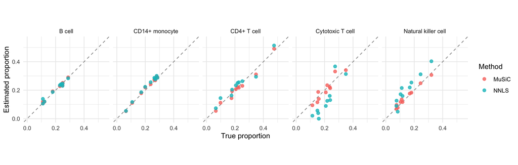

```r
plot_df <- data.frame(
  truth     = c(prop_true_mat, prop_true_mat),
  estimate  = c(music_res$Est.prop.weighted[, select_ct],
                music_res$Est.prop.allgene[, select_ct]),
  cell_type = factor(rep(rep(select_ct, each = n_sample), times = 2),
                     levels = select_ct),
  method    = factor(rep(c("MuSiC", "NNLS"),
                         each = n_sample * length(select_ct)),
                     levels = c("MuSiC", "NNLS")))

gg <- ggplot2::ggplot(plot_df, ggplot2::aes(x = truth, y = estimate)) +
  ggplot2::geom_abline(slope = 1, intercept = 0, colour = "gray60",
                       linetype = "dashed") +
  ggplot2::geom_point(ggplot2::aes(colour = method), size = 2, alpha = 0.8) +
  ggplot2::facet_wrap(~ cell_type, nrow = 1) +
  ggplot2::coord_fixed(xlim = c(0, 0.55), ylim = c(0, 0.55)) +
  ggplot2::labs(x = "True proportion", y = "Estimated proportion",
                colour = "Method") +
  ggplot2::theme_minimal()
plot(gg)
```

The dashed line is where a perfect estimate would sit. B cells and CD14+ monocytes are easy — both methods sit on the line. The interesting panels are the last two: for cytotoxic T cells and NK cells the blue NNLS points scatter well off the diagonal while the red MuSiC points stay close to it.

That is not a coincidence about those two cell types specifically. Break the error down by cell type:

```r
err_music_mat <- abs(music_res$Est.prop.weighted[, select_ct] - prop_true_mat)
err_nnls_mat  <- abs(music_res$Est.prop.allgene[, select_ct]  - prop_true_mat)

round(rbind(MuSiC = colMeans(err_music_mat),
            NNLS  = colMeans(err_nnls_mat)), 4)
```

```
##       B cell CD14+ monocyte CD4+ T cell Cytotoxic T cell Natural killer cell
## MuSiC 0.0048         0.0082      0.0160           0.0253              0.0099
## NNLS  0.0078         0.0141      0.0282           0.0988              0.0587
```

NNLS’s total error is concentrated almost entirely in cytotoxic T cells (0.099) and NK cells (0.059). **These are the two cell types whose expression profiles most resemble each other** — both are cytotoxic lymphocytes sharing granzyme and perforin programmes. When two columns of the reference look alike, the regression cannot tell which one produced the signal, and it splits the difference more or less arbitrarily from sample to sample. MuSiC cuts that error by a factor of four on cytotoxic T cells and six on NK cells.

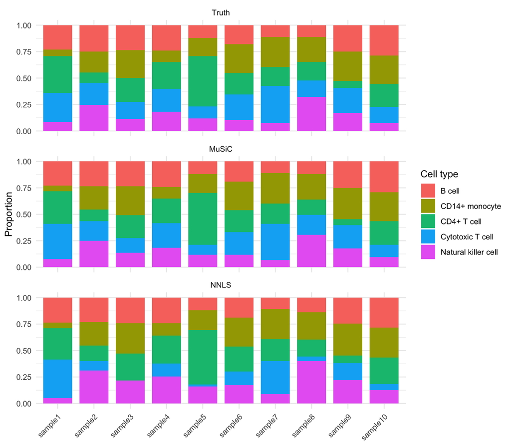

```r
bar_df <- data.frame(
  proportion = c(prop_true_mat,
                 music_res$Est.prop.weighted[, select_ct],
                 music_res$Est.prop.allgene[, select_ct]),
  cell_type  = factor(rep(rep(select_ct, each = n_sample), times = 3),
                      levels = select_ct),
  sample     = factor(rep(rownames(prop_true_mat),
                          times = 3 * length(select_ct)),
                      levels = rownames(prop_true_mat)),
  source     = factor(rep(c("Truth", "MuSiC", "NNLS"),
                          each = n_sample * length(select_ct)),
                      levels = c("Truth", "MuSiC", "NNLS")))

gg <- ggplot2::ggplot(bar_df, ggplot2::aes(x = sample, y = proportion,
                                           fill = cell_type)) +
  ggplot2::geom_col(width = 0.8) +
  ggplot2::facet_wrap(~ source, ncol = 1) +
  ggplot2::labs(x = NULL, y = "Proportion", fill = "Cell type") +
  ggplot2::theme_minimal() +
  ggplot2::theme(axis.text.x = ggplot2::element_text(angle = 45, hjust = 1))
plot(gg)
```

The same result read as composition. The MuSiC panel is close to a copy of the Truth panel. In the NNLS panel the blue and magenta bands — cytotoxic T and NK — visibly trade places against the truth, most obviously in samples 2, 3, 6 and 8, while the red B cell and olive monocyte bands are fine.

# 8 What the weighting actually does

MuSiC’s estimate is a weighted non-negative least squares fit: it solves the same equation NNLS does, but every gene enters with its own weight. The weight is, roughly, the reciprocal of how much that gene’s contribution wobbles — combining the fit residual with the cross-subject variance of the gene’s cell-type-specific expression. Genes that behave consistently get a large weight; genes that jump around get a small one.

```r
weight_vec <- music_res$Weight.gene[, 1]
weight_vec <- weight_vec[!is.na(weight_vec)]
signif(quantile(weight_vec), 3)
```

```
##       0%      25%      50%      75%     100%
## 6.51e-01 6.16e+02 2.87e+03 7.51e+03 1.00e+04
```

The weights span four orders of magnitude within a single sample. The ceiling of 10,000 is not data — it is `1 / nu`, where `nu = 1e-4` is `music_prop()`’s regularization argument, there to stop a perfectly-behaved gene from taking infinite weight.

Which genes get pushed to the bottom?

```r
names(sort(weight_vec))[1:10]
```

```
##  [1] "GNLY"   "IGLC3"  "IGHA1"  "JCHAIN" "FTH1"   "RPL32"  "NEAT1"  "MT-ND3"
##  [9] "RPL28"  "RPL37"
```

`GNLY`, `IGLC3`, `IGHA1`, `JCHAIN`, `FTH1`, ribosomal proteins, a mitochondrial gene. This list is worth staring at, because it looks backwards:

> **Low weight does not mean “bad marker”.** `GNLY` (granulysin) is one of the most informative NK and cytotoxic-T markers there is. MuSiC down-weights it anyway, because the weight measures *consistency*, not *specificity*. `GNLY` is expressed at very high and very variable levels, so its absolute contribution to a bulk sample is noisy, and a noisy gene given full weight drags the fit around. The same goes for ribosomal and mitochondrial genes, which are abundant and unstable. **MuSiC is not selecting markers.** It uses all 18,013 genes and decides how much to trust each one — which is exactly the step marker-based methods skip.

The pattern is systematic — the more of the bulk library a gene accounts for, the lower its weight:

```r
abundance_vec <- bulk_mat[names(weight_vec), 1] / sum(bulk_mat[, 1])
weight_df     <- data.frame(abundance = abundance_vec, weight = weight_vec)
weight_df     <- weight_df[weight_df$abundance > 0, ]
nrow(weight_df)
```

```
## [1] 15651
```

```r
round(cor(log10(weight_df$abundance), log10(weight_df$weight)), 3)
```

```
## [1] -0.695
```

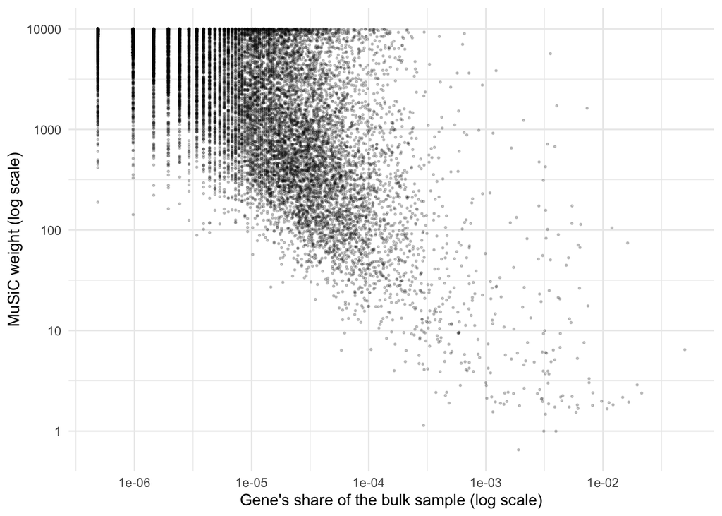

```r
gg <- ggplot2::ggplot(weight_df, ggplot2::aes(x = abundance, y = weight)) +
  ggplot2::geom_point(size = 0.4, alpha = 0.2) +
  ggplot2::scale_x_log10() +
  ggplot2::scale_y_log10() +
  ggplot2::labs(x = "Gene's share of the bulk sample (log scale)",
                y = "MuSiC weight (log scale)") +
  ggplot2::theme_minimal()
plot(gg)
```

A correlation of -0.695 on the log scale across 15,651 genes. The vertical stripes on the left are counts of 1, 2, 3 … — at low abundance the possible values are discrete.

# 9 Breaking it: a reference from the wrong assay

Everything above holds the technology fixed. Let us see what that was worth.

We rerun the identical bulk samples, changing one thing: the reference now comes from the three **10x Chromium v2** runs instead of the v3 cells. Same tissue, same donors, same lab, same paper, same manufacturer — one chemistry generation apart. Here the three separate runs give us three genuine replication units, so `samples` is a real column for once:

```r
v2_vec      <- c("10x Chromium (v2)", "10x Chromium (v2) A",
                 "10x Chromium (v2) B")
keep_v2_vec <- obj$Method %in% v2_vec & obj$CellType %in% select_ct
sum(keep_v2_vec)
```

```
## [1] 8884
```

```r
table(obj$Method[keep_v2_vec])
```

```
##
##   10x Chromium (v2) 10x Chromium (v2) A 10x Chromium (v2) B
##                3174                2818                2892
```

```r
sce_ref_v2 <- SingleCellExperiment::SingleCellExperiment(
  assays  = list(counts = SeuratObject::LayerData(
                   obj, assay = "RNA", layer = "counts")[, keep_v2_vec]),
  colData = data.frame(CellType  = obj$CellType[keep_v2_vec],
                       sample_id = obj$Method[keep_v2_vec],
                       row.names = colnames(obj)[keep_v2_vec]))
```

Note that this reference is **larger** than the one that worked — 8,884 cells against 1,408 — so nothing that follows can be blamed on running short of data.

```r
music_v2_res <- MuSiC::music_prop(bulk.mtx = bulk_mat, sc.sce = sce_ref_v2,
                                  clusters = "CellType", samples = "sample_id",
                                  select.ct = select_ct, verbose = FALSE)

MuSiC::Eval_multi(prop.real = prop_true_mat,
                  prop.est  = list(music_res$Est.prop.weighted,
                                   music_v2_res$Est.prop.weighted),
                  method.name = c("MuSiC, v3 reference",
                                  "MuSiC, v2 reference"))
```

```
##                        RMSD     mAD      R
## MuSiC, v3 reference 0.01720 0.01284 0.9798
## MuSiC, v2 reference 0.13114 0.11640 0.4137
```

Correlation with the truth falls from **0.980 to 0.414**, and mean absolute error rises from 0.013 to 0.116 — an average miss of twelve percentage points on a proportion. Six times the reference cells, nine times the error.

```r
round(music_v2_res$Est.prop.weighted, 3)
```

```
##          B cell CD14+ monocyte CD4+ T cell Cytotoxic T cell Natural killer cell
## sample1   0.203          0.153       0.193            0.261               0.189
## sample2   0.161          0.400       0.000            0.080               0.359
## sample3   0.184          0.481       0.002            0.103               0.230
## sample4   0.211          0.228       0.091            0.182               0.288
## sample5   0.071          0.349       0.275            0.094               0.211
## sample6   0.136          0.455       0.022            0.179               0.208
## sample7   0.076          0.475       0.000            0.235               0.215
## sample8   0.069          0.398       0.000            0.107               0.426
## sample9   0.141          0.485       0.000            0.037               0.337
## sample10  0.225          0.452       0.051            0.072               0.201
```

Look at the `CD4+ T cell` column: exactly zero in four of the ten samples and 0.002 in a fifth, when the truth is between 0.066 and 0.475. The estimate has not become noisy — it has collapsed. A whole cell type has been erased and its mass handed to CD14+ monocytes, which are over-estimated in every one of the ten samples.

```r
round(colMeans(abs(music_v2_res$Est.prop.weighted[, select_ct]
                   - prop_true_mat)), 4)
```

```
##              B cell      CD14+ monocyte         CD4+ T cell    Cytotoxic T cell
##              0.0539              0.1729              0.1614              0.0756
## Natural killer cell
##              0.1181
```

Why does one chemistry generation do this? Because v2 and v3 do not capture mRNA with the same efficiency, and the difference is not a constant factor across genes. The reference’s picture of what a CD4+ T cell looks like is therefore systematically distorted relative to the bulk, and a non-negative fit responds to a distorted column by setting its coefficient to zero and letting a correlated column absorb the signal.

The median library size tells the same story from the other end:

```r
tapply(obj$nCount_RNA, obj$Method, median)[c(v2_vec, "10x Chromium (v3)")]
```

```
##   10x Chromium (v2) 10x Chromium (v2) A 10x Chromium (v2) B   10x Chromium (v3)
##              2627.0              1882.0              2392.0              4508.5
```

4,508.5 UMIs per cell in v3 against 1,882 to 2,627 in the v2 runs — roughly double the depth, and depth is not neutral: it changes which genes are detected at all, and a gene that is zero in the reference but non-zero in the bulk cannot help identify anything.

The crucial part is what you would have noticed **without** ground truth:

```r
round(music_v2_res$r.squared.full, 4)
```

```
##  sample1  sample2  sample3  sample4  sample5  sample6  sample7  sample8
##   0.8079   0.7996   0.7896   0.7998   0.8021   0.7924   0.7985   0.7824
##  sample9 sample10
##   0.7880   0.7957
```

R² falls from 0.9958–0.9997 to 0.7824–0.8079. On real bulk data you cannot check the proportions, but you can always check this — and a drop of this size is the signal that your reference does not describe your bulk samples.

> **The lesson, which is the most portable thing in this tutorial.** Match your reference to your bulk data on assay, chemistry, tissue and, where you can, subject. A bigger reference from the wrong place is worse than a small one from the right place. And read `r.squared.full` every single time — it is the one honest diagnostic available when you have no truth to compare against.

# 10 What we glossed over

- **Our four “donors” are fake.** Section 4.1 shuffled one donor’s cells into four piles so that `music_prop()` had a `samples` column. Real cross-subject variance — the thing MuSiC is actually built to exploit — never entered this analysis, which is part of why the main result is so clean. With real donors you would also want more than four.
- **Our bulk samples are too easy.** They were assembled from single-cell libraries of the same protocol as the reference, so they carry none of the differences that separate a real bulk RNA-seq library from a droplet experiment: full-length rather than 3’-end reads, no UMIs, different amplification, intronic reads from unspliced transcripts. Section 9 is a lower bound on that problem, not an upper one.
- **We never deconvolved anything real.** The natural next step on your own data is bulk samples with no truth attached, where all you have is `r.squared.full`, biological plausibility, and whether the proportions move with a variable you expect them to move with.
- **Collinear cell types have a dedicated tool.** The cytotoxic T / NK confusion in Section 7 is exactly what `MuSiC::music_prop.cluster()` is for: it groups similar cell types, estimates group proportions first, then splits within the group using genes that separate its members. Worth knowing if your cell types are finer-grained than ours.
- **Multi-condition bulk needs MuSiC2.** If your bulk samples come from cases and controls but your reference is all controls, the disease-affected genes bias the fit. `MuSiC::music2_prop()` iterates between estimating proportions and removing genes that behave differently between conditions.
- **Where the cell type labels come from.** We used the authors’ `CellType` column as if handed down. On your own data those labels are an output of the clustering and annotation work from **Week 4**, and every error in them propagates directly into the reference — deconvolution can be no better than the labels it is built on.
- **The reference got no cleaning.** No ambient RNA correction, no doublet removal — the **Week 2** steps — and no normalization choice, since MuSiC normalizes internally rather than using the **Week 3** pipeline. Ambient RNA in particular blurs cell type profiles together, which is precisely the failure mode Section 7 showed.
- **Other deconvolution methods exist**, and several are widely used: CIBERSORTx, BayesPrism, dtangle, bseqsc, SCDC. MuSiC’s own vignette benchmarks against a couple of them. We compared only against the NNLS baseline that `music_prop()` hands back for free.
- **`MuSiC::Prop_comp_multi()` and `Jitter_Est()`** are the package’s built-in plotting functions and will look familiar from the vignette. We drew our own figures instead: `Prop_comp_multi()` fixes its colour scale to the full 0–1 range, so when every proportion sits below 0.5 — as here — the whole heatmap renders in near-identical blues.

# 11 References

- Wang X, Park J, Susztak K, Zhang NR, Li M. *Bulk tissue cell type deconvolution with multi-subject single-cell expression reference.* Nature Communications 10:380, 2019. [doi:10.1038/s41467-018-08023-x](https://doi.org/10.1038/s41467-018-08023-x)
- Fan J, Lyu Y, Zhang Q, Wang X, Xiao R, Li M. *MuSiC2: cell-type deconvolution for multi-condition bulk RNA-seq data.* Briefings in Bioinformatics 23:bbac430, 2022. [doi:10.1093/bib/bbac430](https://doi.org/10.1093/bib/bbac430)
- Ding J, Adiconis X, Simmons SK, *et al.* *Systematic comparative analysis of single-nucleus and single-cell RNA-sequencing methods.* Nature Biotechnology 38:737–746, 2020. [doi:10.1038/s41587-020-0465-8](https://doi.org/10.1038/s41587-020-0465-8) — the source of `pbmcsca`.
- MuSiC tutorial: [xuranw.github.io/MuSiC](https://xuranw.github.io/MuSiC/articles/MuSiC.html)
- `TOAST`: bioconductor.org/packages/TOAST